# Recreating PLoS Results

Reed Scott

2025-02-24

Hello Brittany and Mark!

One of the suggestions I got from our previous meeting was to try to recreate the results of Mihaljevic et al (2014). I have done so, and wanted to report on my findings. I re-created density depedent and frequency dependent models as well as additive and saturated models. This means that there are 4 possible scenarios I’ll be outlining in this report:

1. **Density** dependent disease transmission with an **additive** relationship between abundance and species richness.
2. **Density** dependent disease transmission with a **saturated** relationship between abundance and species richness.
3. **Frequency** dependent disease transmission with an **additive** relationship between abundance and species richness.
4. **Frequency** dependent disease transmission with a **saturated** relationship between abundance and species richness.

I will report on each of these scenarios and how I simulated them. I will also include some concluding remarks on how I think this impacts our simulation and how I want to adjust what I’ve done for our project. I have included at the end my key take aways.

# Paramaters

Many of the parameters used here have already been used previously. I won’t discuss how I decided on their values, as that has already been discussed in other documents. But I did want to recap what parameters are used here.

- num_spp = the number of species
- K = rank abundance of each species
- n_iter = how many simulations we’ll do (I set this at 1000)
- $\psi$ = occupancy
- b = birth rate. All 0 here.
- d = death rate.
- v = recovery rate
- $\beta$ = transmission coefficient

# Reference Graph

For this report, I will frequently reference Figure 1 (below). This is an image taken from Mihaljevic (2014) that I think nicely encapsulates what they did. My goal is to create simulations that match the results shown in this figure. As such, I will be comparing the plots that result from my simulations to panels in this figure.

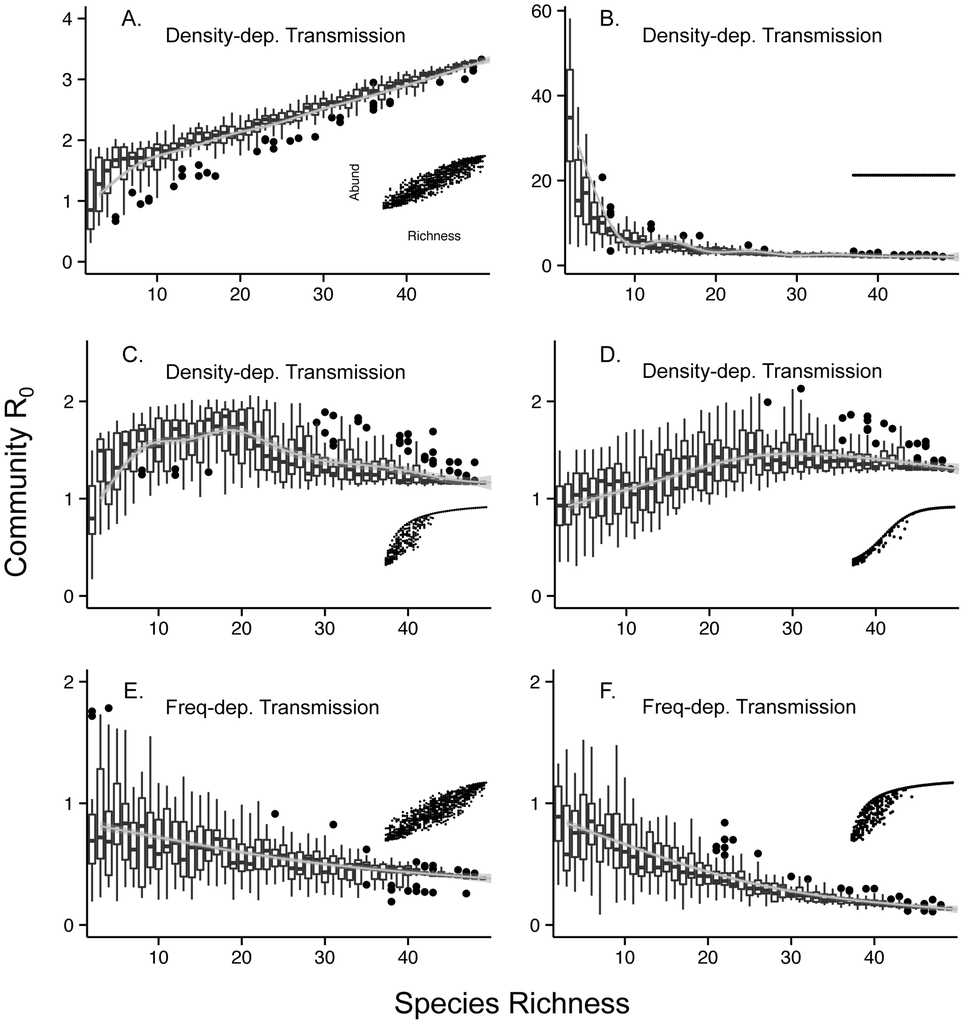

Figure 1: Results from Mihaljevic 2014

# **Density** dependent disease transmission with an **additive** relationship between abundance and species richness.

Okay, so we’re going to start by simulating an additive relationship between abundance and richness. This is relatively simple: *if* a species is present then it is present at it’s rank abundance level. Then, once we’ve determined what species are present, we can use Mihaljevic’s calculation of a “G matrix” and get the max Eigen value of that matrix to determine $R_{0P}$. We can then plot $R_{0P} - Richness$. If we compare this to Fig 1A, it looks like a pretty good match!

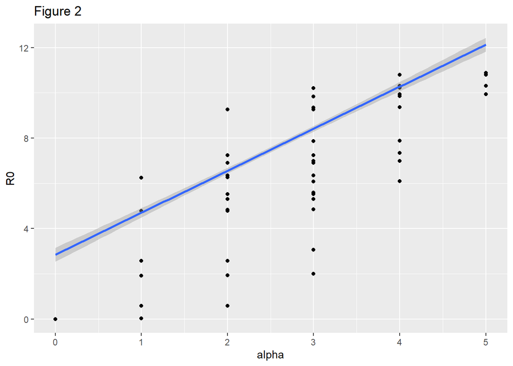

```r
### Density dependent, additive models #
comms_additive <- vector("list", length = n_iter)
for(c in 1:length(comms_additive)){
  N <- rep(NA,6)
  for(i in 1:length(N)){
    N[i] <- ifelse(rbinom(n=1,size=1,prob=psi[i]),K[i],0)
  }
  comms_additive[[c]] <- N
}

den_dep_add_r0 <- vector("list", length = length(comms_additive))
# density dependent model
for(c in 1:length(comms_additive)){
  N <- comms_additive[[c]]
  p <- N
  G <- matrix(NA, nrow = num_spp, ncol = num_spp)
  for(i in 1:num_spp){
    for (j in 1:num_spp) {
      G[i,j] <- (beta[i,j]*p[j])/(v[j]+d[j])
    }
  }
  R0 <- eigen(G)$values[1]
  den_dep_add_r0[[c]] <- R0
}

comms_df <- data.frame(matrix(unlist(comms_additive), nrow = length(comms_additive), ncol = num_spp, byrow = T))
den_dep_add_df <- cbind(comms_df, unlist(den_dep_add_r0))
den_dep_add_df$alpha <- rowSums(den_dep_add_df[,1:6] > 0)
den_dep_add_df$abund <- rowSums(den_dep_add_df[,1:6])
names(den_dep_add_df)[1:7] <- c("Spp1","Spp2","Spp3","Spp4","Spp5","Spp6","R0")
den_dep_add_Plot <- ggplot(data = den_dep_add_df,mapping = aes(x = alpha, y = R0))+
  geom_point()+
  geom_smooth(method = "lm")+
  ggtitle("Figure 2")
den_dep_add_Plot
```

# **Density** dependent disease transmission with a **saturated** relationship between abundance and species richness.

Where $K_{comm}$ is the saturating function for richness and abundance, R is the number of species, 65 represents the max abundance (choosen somewhat arbitrarily) and the rest are constants I’ve played around with a bit. Notice that I also had to create a initial relationship between the number of species and the overall abundance. This is because, in order to make it a saturated model, I made it such that if abundance < $K_{comm}$ then any species present would be present in their max abundance, while if abundance >= $K_{comm}$ abundance were adjusted based on the variable $K_S$ which is equal to $K_{comm}/K_T$. More info on all of this can be found in the supplementals of Mihaljevic et al. All of this said, if you look at Fig 3 it decently matches Fig 1C.

*Please note: I have found that the exact shape of the saturated richness - abundance curve is highly sensitive to the constants used in calculating* *$K_{comm}$. If we go this route for simulating abundance (and I personally think we should), we will have to choose constants carefully*

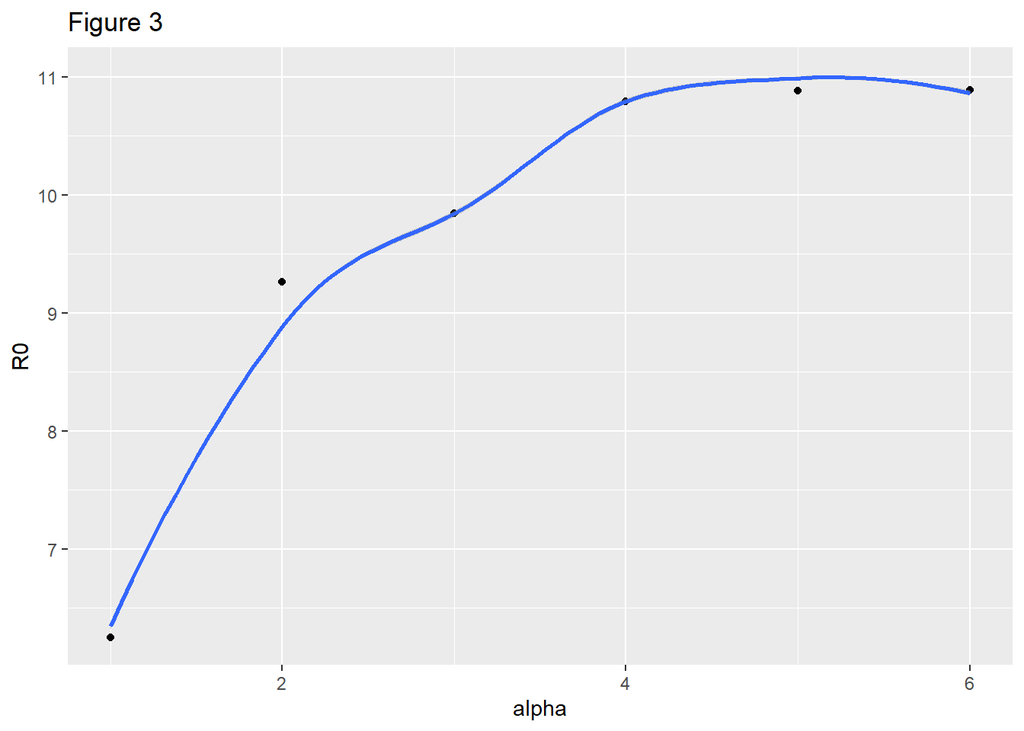

```r
max_abund <- 65

species_richness <- as.numeric(sample(1:6, size = n_iter, replace = T))

#need to create a relationship between species richness and abundance
a <- 6
b <- 4
error <- rnorm(length(species_richness), mean = 0, sd = 1)
abundance <- a*log(b*species_richness)+error
#plot(species_richness,abundance)

rich_abund <- data.frame(richness = species_richness, abundance = abundance)
comms_saturated <- vector("list", length = n_iter)
KCOM_list <- vector("list", length = n_iter)
for(c in 1:length(comms_saturated)){
  R <- rich_abund[c,1]
  KCOM <- max_abund/(1+6*exp(-0.15*(R+10)))
  KS <- KCOM/rich_abund[c,2]
  comms_saturated[[c]] <- if(rich_abund[c,2] >= KCOM){
    c(K[1:rich_abund[c,1]]*KS,rep(0, num_spp - rich_abund[c,1]))} else{
      c(K[1:rich_abund[c,1]],rep(0, num_spp - rich_abund[c,1]))
    }
  KCOM_list[[c]] <- KCOM
}

#Okay, so let's unlist these and then create a df from them
# comms_sat_df <- data.frame(matrix(unlist(comms_saturated), nrow = length(comms_saturated), ncol = num_spp, byrow = T))
# comms_sat_df$abund <- rowSums(comms_sat_df)
# comms_sat_df$rich <- rich_abund$richness
# comms_sat_df$KCOM <- unlist(KCOM_list)
# plot(comms_sat_df$rich, comms_sat_df$abund)
# comms_sat_plot <- ggplot(data = comms_sat_df, mapping = aes(x = rich, y = abund))+
#   geom_point(position = position_dodge(width = 0.9))+
#   geom_smooth()+
# comms_sat_plot



# Okay so I've now shown that this is a saturated model. Let's check out the disease effect
# density dependent SATURATED MODEL model
den_dep_sat_r0 <- vector("list", length = length(comms_saturated))
for(c in 1:length(comms_saturated)){
  N <- comms_saturated[[c]]
  p <- N
  G <- matrix(NA, nrow = num_spp, ncol = num_spp)
  for(i in 1:num_spp){
    for (j in 1:num_spp) {
      G[i,j] <- (beta[i,j]*p[j])/(v[j]+d[j])
    }
  }
  R0 <- eigen(G)$values[1]
  den_dep_sat_r0[[c]] <- R0
}

comms_den_sat_df <- data.frame(matrix(unlist(comms_saturated), nrow = length(comms_saturated), ncol = num_spp, byrow = T))
den_dep_sat_df <- cbind(comms_den_sat_df, unlist(den_dep_sat_r0))
den_dep_sat_df$alpha <- rowSums(den_dep_sat_df[,1:6] > 0)
den_dep_sat_df$abund <- rowSums(den_dep_sat_df[,1:6])
names(den_dep_sat_df)[1:7] <- c("Spp1","Spp2","Spp3","Spp4","Spp5","Spp6","R0")
den_dep_sat_Plot <- ggplot(data = den_dep_sat_df,mapping = aes(x = alpha, y = R0))+
  geom_point()+
  geom_smooth(method = "loess")+
  ggtitle("Figure 3")
den_dep_sat_Plot
```

# **Frequency** dependent disease transmission with an **additive** relationship between abundance and species richness.

So, when we model a frequency dependent system there are a few changes in how we construct the G matrix and thus how we calculate $R_{0P}$. The key difference is in parameter p. I didn’t talk about it before but p changes depending on whether or not disease tranmission is density dependent or frequency dependent. In a density dependent system, p is simply equal to the total abundance of infecting species (N[j] in our case). However, in a frequency dependent system, p is equal to *relative* abundance of the infecting species or $p = N_j/(\sum_{i}^{numspp}N)$. In coding practice, this takes the following form:

```
for(c in 1:length(comms_freq_saturated)){
  N <- comms_freq_saturated[[c]]
  p <- N
  G <- matrix(NA, nrow = num_spp, ncol = num_spp)
  for(i in 1:num_spp){
    for (j in 1:num_spp) {
      trans <- if(sum(p) > 0){
        p[j]/sum(p)} else{0}=
      G[i,j] <- (beta[i,j]*trans)/(v[j]+d[j])
    }
  }
  R0 <- eigen(G)$values[1]
  freq_dep_sat_r0[[c]] <- if(R0 > 0){
    R0} else{NA}
}
```

And when we combine the frequency dependent disease model with an additive species - abundance relationship we get the Figure 4. I think this matches well with Figure 1E and shows a dilution effect.

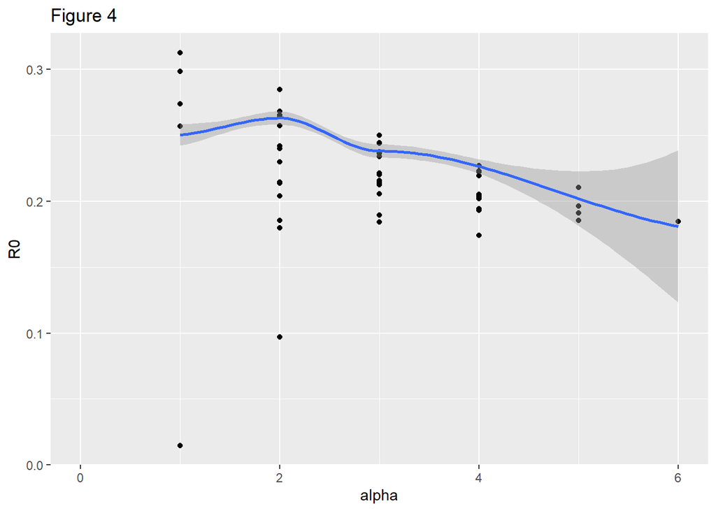

# **Frequency** dependent disease transmission with a **saturated** relationship between abundance and species richness.

Lastly we have frequency dependent transmission with a saturated richness - abundance relationship. Everything about this has already been explained in previous parts (how to make a frequency dependent model, how to create a saturated model) so I won’t rehash it here. The results are shown in Figure 5, which shows a more exaggerated dilution effect but I believe match the same trend as Figure 1F.

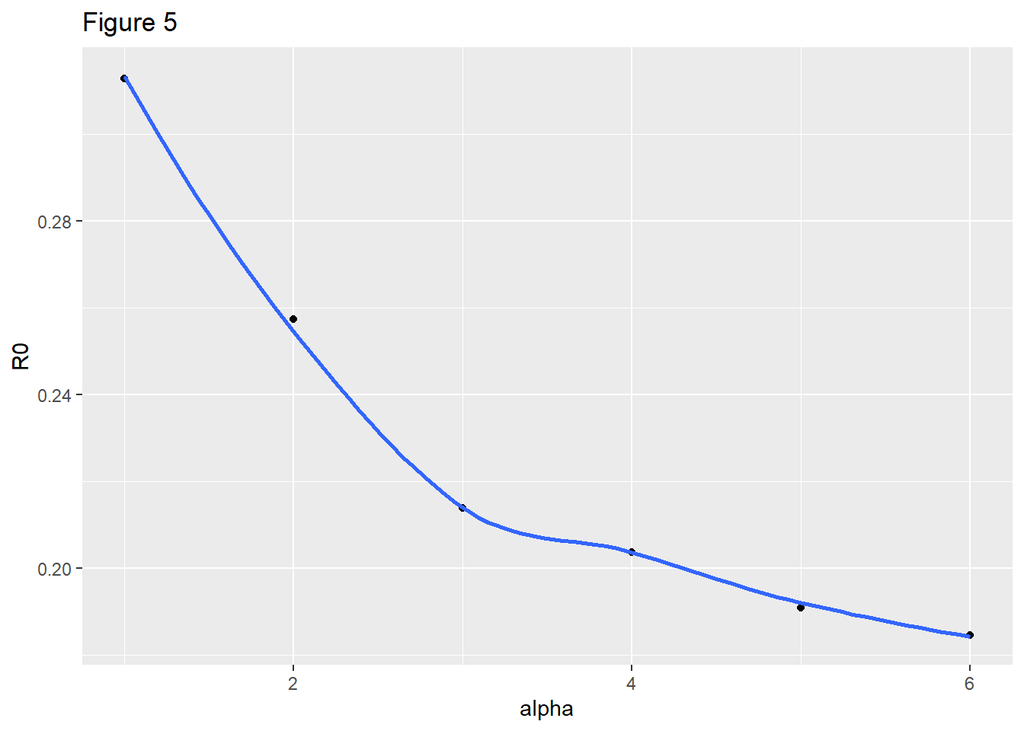

# Conclusion

I have come away from this exercise with a much better understanding of the potential ways of forming a community. I can also see how this directly applies to our project. I’m thankful you both recommended I go through and do this. **My key take away from this: I think we should build our** **metacommunity disease model using a frequency dependent disease system and a saturated relationship between richness and abundance.** Now that I have this practice I think this should be pretty straightforward to adapt to our system.